# Situación Problema: Contaminación ambiental y salud en México

Author

Marissa Luna, Mariana León, Nube Garcidueñas, Ximena Cantón.

Los contaminantes del aire, como el material particulado (PM₂.₅ y PM₁₀), el dióxido de azufre (SO₂), el monóxido de carbono (CO), los óxidos de nitrógeno (NOx), los compuestos orgánicos volátiles (COV) y el amoníaco (NH₃), se relacionan entre sí por su origen (industrial, vehicular) y por reacciones químicas que forman otros compuestos. Estos contaminantes impactan a los biomarcadores al provocarles cambios en su estructura o función, lo que se traduce en un indicador de exposición o daño orgánico. Los biomarcadores afectados suelen ser macromoléculas como proteínas, lípidos o carbohidratos, entre otros. “La exposición a la contaminación del aire está asociada con el estrés oxidativo y la inflamación de las células humanas, lo que puede sentar las bases para enfermedades crónicas y el cáncer” (NIH, s.f.).

Estos procesos impactan distintos biomarcadores biológicos, entre los que destacan: • Marcadores hematológicos: reducción de hemoglobina • Marcadores de inflamación: proteína C reactiva (PCR). • Marcadores cardiovasculares y metabólicos: presión arterial, glucosa, colesterol y triglicéridos. • Marcadores de función pulmonar. En conjunto, la exposición a contaminantes puede alterar parámetros sanguíneos y respiratorios, aumentando el riesgo de enfermedades crónicas cardiovasculares, respiratorias y metabólicas.

# 1. Conjunto de Datos

*✏️ Una vez que cuenten con una selección de variables que les satisfaga, construyan el conjunto de datos que utilizarán. Para ello será necesario unir diferentes tablas para obtener la información necesaria.*

```r
#utilizamos ambiente de anaconda para cagar python
library(reticulate)
use_condaenv("base", required = TRUE)
```

```python
import pandas as pd
```

```python
muestras= pd.read_csv("data/ensanut2022_muestras.csv", sep=";", decimal=",", encoding="utf-8-sig")
socdem= pd.read_csv("data/ensanut2022_socdem.csv", sep=";", decimal=",", encoding="utf-8-sig")
aire= pd.read_csv("data/calidad_aire_2025.csv")
```

```python
#Creamos diccionario para que todo los estados estén escritos igual
map_estados = {
    # Aguascalientes
    "01 AGUASCALIENTES": "Aguascalientes",
    "Aguascalientes": "Aguascalientes",

    # Baja California
    "02 BAJA CALIFORNIA": "Baja california",
    "Baja California": "Baja california",

    # Baja California Sur
    "03 BAJA CALIFORNIA SUR": "Baja california sur",
    "Baja California Sur": "Baja california sur",

    # Campeche
    "04 CAMPECHE": "Campeche",
    "Campeche": "Campeche",

    # Coahuila
    "05 COAHUILA DE ZARAGOZA": "Coahuila",
    "Coahuila": "Coahuila",

    # Colima
    "06 COLIMA": "Colima",
    "Colima": "Colima",

    # Chiapas
    "07 CHIAPAS": "Chiapas",
    "Chiapas": "Chiapas",

    # Chihuahua
    "08 CHIHUAHUA": "Chihuahua",
    "Chihuahua": "Chihuahua",

    # Ciudad de México
    "09 CIUDAD DE MÉXICO": "Ciudad de mexico",
    "Ciudad de México": "Ciudad de mexico",

    # Durango
    "10 DURANGO": "Durango",
    "Durango": "Durango",

    # Guanajuato
    "11 GUANAJUATO": "Guanajuato",
    "Guanajuato": "Guanajuato",

    # Guerrero
    "12 GUERRERO": "Guerrero",
    "Guerrero": "Guerrero",

    # Hidalgo
    "13 HIDALGO": "Hidalgo",
    "Hidalgo": "Hidalgo",

    # Jalisco
    "14 JALISCO": "Jalisco",
    "Jalisco": "Jalisco",

    # Estado de México
    "15 MÉXICO": "Estado de mexico",
    "Estado de México": "Estado de mexico",

    # Michoacán
    "16 MICHOACÁN DE OCAMPO": "Michoacan",
    "Michoacán": "Michoacan",

    # Morelos
    "17 MORELOS": "Morelos",
    "Morelos": "Morelos",

    # Nayarit
    "18 NAYARIT": "Nayarit",
    "Nayarit": "Nayarit",

    # Nuevo León
    "19 NUEVO LEÓN": "Nuevo leon",
    "Nuevo León": "Nuevo leon",

    # Oaxaca
    "20 OAXACA": "Oaxaca",
    "Oaxaca": "Oaxaca",

    # Puebla
    "21 PUEBLA": "Puebla",
    "Puebla": "Puebla",

    # Querétaro
    "22 QUERÉTARO": "Queretaro",
    "Querétaro": "Queretaro",

    # Quintana Roo
    "23 QUINTANA ROO": "Quintana roo",
    "Quintana Roo": "Quintana roo",

    # San Luis Potosí
    "24 SAN LUIS POTOSÍ": "San luis potosi",
    "San Luis Potosí": "San luis potosi",

    # Sinaloa
    "25 SINALOA": "Sinaloa",
    "Sinaloa": "Sinaloa",

    # Sonora
    "26 SONORA": "Sonora",
    "Sonora": "Sonora",

    # Tabasco
    "27 TABASCO": "Tabasco",
    "Tabasco": "Tabasco",

    # Tamaulipas
    "28 TAMAULIPAS": "Tamaulipas",
    "Tamaulipas": "Tamaulipas",

    # Tlaxcala
    "29 TLAXCALA": "Tlaxcala",
    "Tlaxcala": "Tlaxcala",

    # Veracruz
    "30 VERACRUZ DE IGNACIO DE LA LLAVE": "Veracruz",
    "Veracruz": "Veracruz",

    # Yucatán
    "31 YUCATÁN": "Yucatan",
    "Yucatán": "Yucatan",

    # Zacatecas
    "32 ZACATECAS": "Zacatecas",
    "Zacatecas": "Zacatecas"
}
```

```python
#mapeamos el diccionario a los nombre de estados a cambiar
import re
socdem["Entidad"] = socdem["desc_ent1"].map(map_estados)
aire["Entidad"]= aire["Entidad"].map(map_estados)
muestras["Entidad"] = muestras["desc_ent"].map(map_estados)
```

```python
#agrupamos por Entidad para facilitar el merge
aire= aire.groupby("Entidad")[["SO_2", "CO","NOx", "COV", "PM_010", "PM_2_5", "NH_3" ]].sum().reset_index()
```

```python
#merge entre aire y socdem
df_joined = pd.merge(socdem, aire, on = "Entidad", how = "inner")
df_joined
```

```
             FOLIO_I         FOLIO_INT  id_int  ...     PM_010    PM_2_5       NH_3
0      2022_01001001  2022_01001001_01       1  ...   5730.027  3040.429  46759.670
1      2022_01001001  2022_01001001_02       2  ...   5730.027  3040.429  46759.670
2      2022_01001002  2022_01001002_01       1  ...   5730.027  3040.429  46759.670
3      2022_01001002  2022_01001002_02       2  ...   5730.027  3040.429  46759.670
4      2022_01001003  2022_01001003_01       1  ...   5730.027  3040.429  46759.670
...              ...               ...     ...  ...        ...       ...        ...
36478  2022_32056029  2022_32056029_02       2  ...  15458.672  7231.974  14415.775
36479  2022_32056029  2022_32056029_03       3  ...  15458.672  7231.974  14415.775
36480  2022_32056029  2022_32056029_04       4  ...  15458.672  7231.974  14415.775
36481  2022_32056030  2022_32056030_01       1  ...  15458.672  7231.974  14415.775
36482  2022_32056030  2022_32056030_02       2  ...  15458.672  7231.974  14415.775

[36483 rows x 162 columns]
```

```python
#merge entre df_final y muestras
df_final = pd.merge(df_joined, muestras, on = "FOLIO_INT", how = "left")
df_final
```

```
           FOLIO_I_x         FOLIO_INT  ...          upm_y  Entidad_y
0      2022_01001001  2022_01001001_01  ...            NaN        NaN
1      2022_01001001  2022_01001001_02  ...            NaN        NaN
2      2022_01001002  2022_01001002_01  ...            NaN        NaN
3      2022_01001002  2022_01001002_02  ...            NaN        NaN
4      2022_01001003  2022_01001003_01  ...            NaN        NaN
...              ...               ...  ...            ...        ...
36478  2022_32056029  2022_32056029_02  ...            NaN        NaN
36479  2022_32056029  2022_32056029_03  ...  3205600011061  Zacatecas
36480  2022_32056029  2022_32056029_04  ...            NaN        NaN
36481  2022_32056030  2022_32056030_01  ...            NaN        NaN
36482  2022_32056030  2022_32056030_02  ...  3205600011061  Zacatecas

[36483 rows x 294 columns]
```

```python
#elegimos las columnas finales
columnas= ["NH_3", "valor_INSULINA", "valor_CREAT", "CO", "valor_HB1AC"
           , "h0303_x", "h0302_x", "estrato_x", "SO_2", "NOx", "valor_VIT_D", "valor_STFR_FEB23", "valor_PCR", "valor_ALBU"]
df_finalisimo= df_final[columnas]
```

```python
#vemos si hay Nan
df_finalisimo.isna().sum()
```

```
NH_3                    0
valor_INSULINA      22584
valor_CREAT         22584
CO                      0
valor_HB1AC         22584
h0303_x                 0
h0302_x                 0
estrato_x               0
SO_2                    0
NOx                     0
valor_VIT_D         22584
valor_STFR_FEB23    22584
valor_PCR           22584
valor_ALBU          22584
dtype: int64
```

```python
#vemos si hay espacios vacíos

#revismaos que vengan desde los df originales
muestras["valor_HB1AC"].str.contains(r'^\s*$', na=False).sum() #hay un monton de espacios
```

```
np.int64(11836)
```

```python
#dropeamos vacíos y Nan
import numpy as np
df_finalisimo = df_finalisimo.replace(r'^\s*$', np.nan, regex=True)
df_finalisimo = df_finalisimo.dropna().reset_index(drop=True)
```

```python
#renombramos las columnas
df_finalisimo
```

```
          NH_3 valor_INSULINA valor_CREAT  ...  valor_STFR_FEB23 valor_PCR  valor_ALBU
0    46759.670           18,1         ,65  ...               1,1      2,23         3,8
1    46759.670           14,9         ,69  ...                ,8       ,21           4
2    46759.670             11          ,6  ...               1,2       ,25           4
3    46759.670            6,1         ,54  ...               1,2       ,12         4,5
4    46759.670             32         ,82  ...                ,9       ,14           4
..         ...            ...         ...  ...               ...       ...         ...
589  14415.775             10         ,35  ...               1,2       ,49         2,1
590  14415.775           11,7         ,48  ...                ,8      1,48         3,6
591  14415.775           17,7          ,4  ...               1,6        ,4         2,4
592  14415.775              7         ,56  ...                ,9       ,42         2,8
593  14415.775            3,3          ,4  ...                 1       ,02         2,4

[594 rows x 14 columns]
```

```python
df_finalisimo.columns = ["Am", "I", "C", "M", "H", "E", "S", "U", "D", "O", "VD", "T", "PCR", "AL"]
```

```python
#rempalzamos comas. por puntos y los hacemos float
df_finalisimo = df_finalisimo.apply(lambda col:
    col.astype(str).str.replace(",", ".", regex=False).astype(float)
)
```

```python
#cambiamos a int U y S
df_finalisimo['U'] = df_finalisimo['U'].astype(int)
df_finalisimo['S'] =df_finalisimo['S'].astype(int)
```

```python
df_finalisimo.head()
```

```
         Am     I     C          M    H  ...          O    VD    T   PCR   AL
0  46759.67  18.1  0.65  72606.138  5.9  ...  23274.641  16.5  1.1  2.23  3.8
1  46759.67  14.9  0.69  72606.138  5.6  ...  23274.641  14.3  0.8  0.21  4.0
2  46759.67  11.0  0.60  72606.138  5.2  ...  23274.641  12.0  1.2  0.25  4.0
3  46759.67   6.1  0.54  72606.138  4.4  ...  23274.641  20.7  1.2  0.12  4.5
4  46759.67  32.0  0.82  72606.138  5.4  ...  23274.641  21.0  0.9  0.14  4.0

[5 rows x 14 columns]
```

```python
df_finalisimo.info()
```

```
<class 'pandas.core.frame.DataFrame'>
RangeIndex: 594 entries, 0 to 593
Data columns (total 14 columns):
 #   Column  Non-Null Count  Dtype
---  ------  --------------  -----
 0   Am      594 non-null    float64
 1   I       594 non-null    float64
 2   C       594 non-null    float64
 3   M       594 non-null    float64
 4   H       594 non-null    float64
 5   E       594 non-null    float64
 6   S       594 non-null    int64
 7   U       594 non-null    int64
 8   D       594 non-null    float64
 9   O       594 non-null    float64
 10  VD      594 non-null    float64
 11  T       594 non-null    float64
 12  PCR     594 non-null    float64
 13  AL      594 non-null    float64
dtypes: float64(12), int64(2)
memory usage: 65.1 KB
```

```python
df_finalisimo.to_csv("data/datos_contaminacion.csv", index=False)
```

## 2. Ajuste de red Gaussiana y Scores.

*✏️ Ajusten una GBN para cada una de las DAG propuestas. ✏️ Reporten el BIC y el AIC para cada GBN*

```r
library(tidyverse)
library(bnlearn)
```

```r
data = read_csv("/Users/marissaluna/Documents/SP_CONTAMINACION/data/datos_contaminacion.csv")
head(data)
```

| Am | I | C | M | H | E | S | U | D | O | VD | T | PCR | AL |
| --- | --- | --- | --- | --- | --- | --- | --- | --- | --- | --- | --- | --- | --- |
| 46759.67 | 18.1 | 0.65 | 72606.14 | 5.9 | 30 | 2 | 3 | 3806.754 | 23274.64 | 16.5 | 1.1 | 2.23 | 3.8 |
| 46759.67 | 14.9 | 0.69 | 72606.14 | 5.6 | 49 | 2 | 3 | 3806.754 | 23274.64 | 14.3 | 0.8 | 0.21 | 4.0 |
| 46759.67 | 11.0 | 0.60 | 72606.14 | 5.2 | 43 | 2 | 3 | 3806.754 | 23274.64 | 12.0 | 1.2 | 0.25 | 4.0 |
| 46759.67 | 6.1 | 0.54 | 72606.14 | 4.4 | 28 | 2 | 3 | 3806.754 | 23274.64 | 20.7 | 1.2 | 0.12 | 4.5 |
| 46759.67 | 32.0 | 0.82 | 72606.14 | 5.4 | 49 | 2 | 3 | 3806.754 | 23274.64 | 21.0 | 0.9 | 0.14 | 4.0 |
| 46759.67 | 9.8 | 1.01 | 72606.14 | 5.3 | 34 | 2 | 3 | 3806.754 | 23274.64 | 40.2 | 1.1 | 10.20 | 4.3 |

```r
data = data |>
        select(c(-U,-S)) # Dropeamos S y U
```

Creamos la DAG 1:

```r
dag1= model2network("[Am][M][D][O][E][PCR|Am:M:D:O:E:VD][VD|E][AL|E:PCR][T|E:PCR][I|E:PCR:VD:AL][C|E:Am:D:O][H|E:M:PCR:T]")
```

Visualizamos la DAG 1:

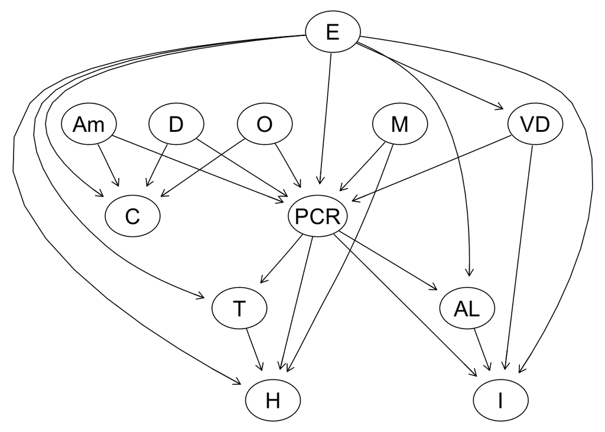

```r
graphviz.plot(dag1, shape = "ellipse")
```

Ahora, realizamos el ajuste para la DAG 1:

```r
dag1_fit = bn.fit(dag1, data=data)
```

Sacamos el BIC de la DAG 1:

```r
score(dag1, data= data, type = "bic-g")
```

```
[1] -39372.28
```

Sacamos el AIC de la DAG 1:

```r
score(dag1, data= data, type = "aic-g")
```

```
[1] -39269.18
```

Creamos la DAG 2:

```r
dag2 = model2network("[M][E][O|M][D|M][Am|M][AL|E][PCR|AL:E][T|PCR][VD|PCR:E][C|E][H|E][I|E:O]")# Le metemos la esctrutura de la DAG
```

Visualizamos la DAG 2:

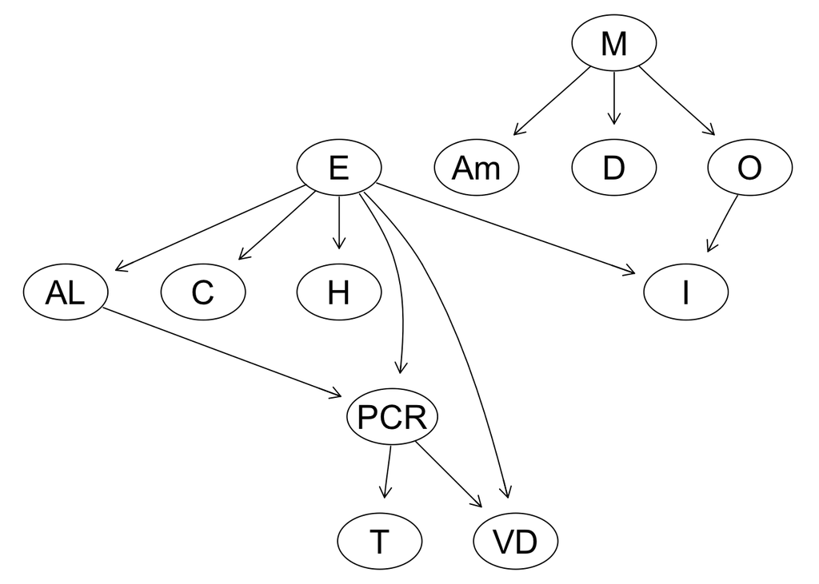

```r
graphviz.plot(dag2, shape = "ellipse")
```

Ahora, realizamos el ajuste para la DAG 2:

```r
dag2_fit = bn.fit(dag2, data=data)
```

Sacamos el BIC de la DAG 2:

```r
score(dag2, data= data, type = "bic-g")
```

```
[1] -39236.12
```

Sacamos el AIC de la DAG 2:

```r
score(dag2, data= data, type = "aic-g")
```

```
[1] -39154.96
```

Creamos la DAG 3:

```r
dag3 = empty.graph(nodes = c( "Am", "I", "C", "M", "H", "E", "O", "D", "VD", "T", "PCR", "AL"))
arc_set = matrix(c(
                   "Am", "C",
                   "Am", "PCR",
                   "Am", "VD",
                   "M", "C",
                   "M", "PCR",
                   "M", "VD",
                   "D", "C",
                   "D", "PCR",
                   "D", "VD",
                   "O", "C",
                   "O", "PCR",
                   "O", "VD",
                   "VD", "I",
                   "I", "H",
                   "E", "C",
                   "E", "H",
                   "PCR", "AL",
                   "PCR", "T",
                   "T", "H"
                   ), byrow = TRUE, ncol = 2,
                 dimnames = list(NULL, c("from", "to")))
```

```r
arcs(dag3) = arc_set
```

Visualizamos la DAG 3:

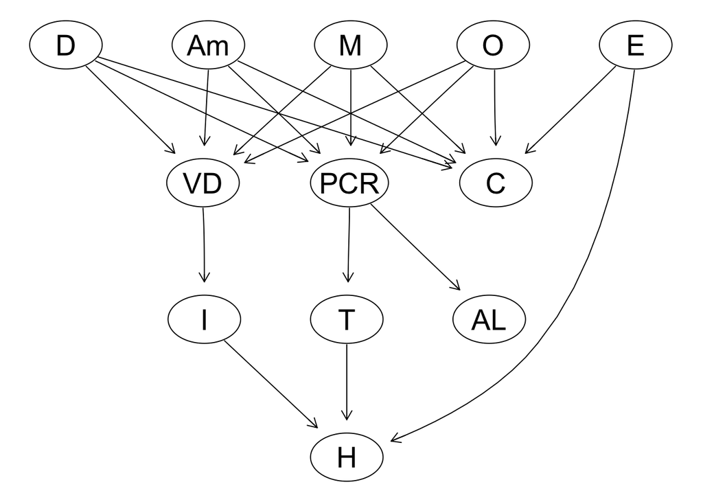

```r
graphviz.plot(dag3, shape = "ellipse")
```

Ahora, realizamos el ajuste para la DAG 3:

```r
dag3_fit = bn.fit(dag3, data=data)
```

Sacamos el BIC de la DAG 3:

```r
score(dag3, data= data, type = "bic-g")
```

```
[1] -39371.72
```

Sacamos el AIC de la DAG 3:

```r
score(dag3, data= data, type = "aic-g")
```

```
[1] -39277.4
```

## 3. Inclusión de variables categóricas

*✏️ Investiguen y discutan cómo podrían incluir las variables categóricas a la red, por ejemplo, una variable de interés puede ser el sexo. Se pueden incluir como nuevos nodos padre en la mejor DAG, de modo que no afecte las relaciones en la DAG ya establecida como la mejor.*

Si ya se tiene una GBN (red bayesiana gaussiana) y se busca añadir un par de variables categóricas, lo ideal para incluirlas, es seguir las siguientes “reglas”:

- Nodos discretos (variables categóricas) no pueden tener padres continuos.
- Nodos continuos (biomarcadores, contaminantes) sí pueden tener padres discretos y continuo.

Por tanto, se orientan los arcos de lo discreto → a lo continuo.

- No cambiar la DAG existente; sólo agregar pocos arcos salientes desde cada variable categórica a los biomarcadores/variables continuas.

## 4. Usando sexo (S) y urbanidad (U)

*✏️ Con la mejor estructura que han encontrado hasta el momento, intenten incluir el sexo de las personas.*

```r
best_dag = model2network("[U][M][E][S][O|U][D|U:M][Am|M][AL|U:E][PCR|AL:E:S][T|PCR][VD|S:PCR:E][C|E:S][H|S:E][I|S:E]")
```

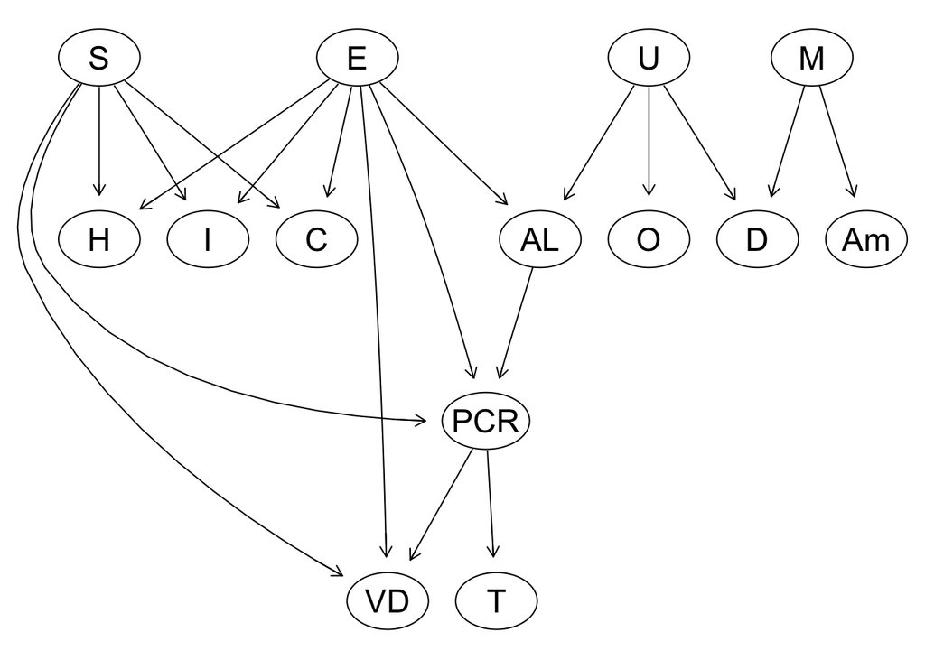

```r
graphviz.plot(best_dag, shape = "ellipse")
```

## 5. Querys

*✏️ Con ayuda de las personas especialistas propongan al menos 3 queries que podrían resolver utilizando su red bayesiana y respóndalas usando su mejor modelo.*

1. ¿Qué probabilidad hay de que una persona de 45 años, tenga la insulina alta si fijamos los contaminantes en valores específicos? Supuesto: NOx=60, SO₂=40, CO=6, NH₃=10 y Edad=45.

```r
# I: Insulina, O: NOx, D: SO₂, M: CO, Am: NH₃, E: Edad
cpquery(dag2_fit,event    = (I > 12),evidence = list(O = 60, D = 40, M = 6, Am = 10, E = 45), method   = "lw")
```

```
[1] 0.5052973
```

2. ¿Qué probabilidad hay de que la creatinina salga alta durante episodios de alta contaminación? Escenario: (NOx > 50) o (CO ≥ 6 y SO₂ ≥ 40).

```r
# C: Creatinina
cpquery(dag2_fit, event    = (C >= 1.3), evidence = ((O > 50) | (M >= 6 & D >= 40)),n = 10^6)
```

```
[1] 0.004217695
```

3. ¿Qué probabilidad hay de que la hemoglobina esté en rango de diabetes (≥ 6.5%) cuando una persona adulta ya tiene insulina alta y está expuesta a contaminantes? Escenario: Adultos (E ≥ 40) con hiperinsulinemia (I ≥ 12) y exposición alta a NOx o SO₂.

```r
# H: HbA1c, I: Insulina, O: NOx, D: SO₂, E: Edad
cpquery(dag2_fit,event    = (H >= 6.5),evidence = (E >= 40 & I >= 12 & (O >= 50 | D >= 40)),n = 10^6)
```

```
[1] 0.3292323
```

## 6. Modelos no paramétricos para mejorar BIC y AIC

*✏️ Investiguen si incluir modelos no paramétricos les ayuda a mejorar el BIC y el AIC de su mejor modelo.*

Se espera que los modelos no paramétricos, como los GAMs que se implementan con las librerías mgcv y gratia, mejoren indicadores como el AIC y el BIC porque permiten mayor flexibilidad en la forma de la relación entre las variables. A diferencia de un modelo lineal, que asume que la relación es recta y constante en toda la muestra, un GAM puede incorporar suavizadores que capturan curvaturas o cambios en la pendiente de manera automática. Esto significa que el modelo tiene más capacidad para reflejar la realidad de los datos sin necesidad de imponer una forma rígida desde el inicio. Por eso, al anticipar que las relaciones no siempre serán lineales, es razonable esperar que un GAM logre un mejor ajuste general y, con ello, ofrezca valores de AIC y BIC más bajos.

```r
library("mgcv")
library("gratia")
```

```r
mod_gam_O = gam(O~s(M), data = data, method = "REML")
mod_gam_D = gam(D ~s(M), data = data, method = "REML")
mod_gam_Am = gam(Am~ s(M), data = data, method = "REML")
mod_gam_AL = gam(AL~s(E), data = data, method = "REML")
mod_gam_PCR = gam(PCR~ s(AL) + s(E), data = data, method = "REML")
mod_gam_T = gam(T ~s(PCR), data = data, method = "REML")
mod_gam_VD = gam(VD ~s(PCR) + s(E), data = data, method = "REML")
mod_gam_C = gam(C~ s(E), data = data, method = "REML")
mod_gam_H = gam(H~s(E), data = data, method = "REML")
mod_gam_I = gam(PCR~ s(E) , data = data, method = "REML")
```

```r
mod_M = lm(M ~ 1, data = data)
mod_E = lm(E ~ 1, data = data)
```

```r
-1/2* (BIC(mod_gam_O) + BIC (mod_gam_D) + BIC (mod_gam_Am) + BIC (mod_gam_AL) + BIC (mod_gam_PCR) + BIC (mod_gam_T) +BIC(mod_gam_VD)+BIC(mod_gam_C)+ BIC (mod_gam_H) +BIC(mod_gam_I)+ BIC (mod_M)+BIC(mod_E))
```

```
[1] -37400.06
```

## Referencias

- National Institute of Environmental Health Sciences. (s. f.). La contaminación del aire y su salud. Recuperado el 6 de septiembre de 2025, de https://www.niehs.nih.gov/health/topics/enfermedades/contaminacion
- Buonaurio, F., Bianco, A., D’Ambrosio, F., Mazzoli, A., Trotta, A., & Sisto, R. (2022). Biomonitoring of exposure to urban pollutants and oxidative stress during the COVID-19 lockdown in Rome residents. Toxics, 10(5), 267. https://doi.org/10.3390/toxics10050267
- Madsen, A. L., Olesen, K. G., Jensen, F., Henriksen, P. A., Larsen, T. M., & Møller, J. M. (2022). Online updating of conditional linear Gaussian Bayesian networks. En A. Salmerón & R. Rumi (Eds.), Proceedings of the 11th International Conference on Probabilistic Graphical Models (Vol. 186, pp. 97–108). PMLR Press. https://proceedings.mlr.press/v186/madsen22a.html